# AI & Machine Learning - Unit 2

# Backprop

$$\chain{\mathcal{L}}{\mbf{W}^1} = \underbrace{\chain{\loss}{\mbf{z}}}_{1\times Z}\underbrace{\chain{\mbf{z}}{\sigma}}_{Z\times \Sigma}\underbrace{\chain{\mbf{\sigma}}{\mbf{h}}\chain{\mbf{h}}{\mbf{W}^1}}_{\chain{\mbf{\sigma}}{\mbf{W}^1}}$$$$f : \mbf{h} \mapsto \sigma \quad \text{vector to vector} \quad \text{- ReLU activation}$$$$ \chain{\mbf{\sigma}}{\mbf{h}} = ~?; \quad \mbf{h}_i = \max(0,\sigma_i) ~~\forall i \in 0\ldots\Sigma$$

# Backprop

$$\chain{\mathcal{L}}{\mbf{W}^1} = \underbrace{\chain{\loss}{\mbf{z}}}_{1\times Z}\underbrace{\chain{\mbf{z}}{\sigma}}_{Z\times \Sigma}\underbrace{\chain{\mbf{\sigma}}{\mbf{h}}\chain{\mbf{h}}{\mbf{W}^1}}_{\chain{\mbf{\sigma}}{\mbf{W}^1}}$$$$f : \mbf{h} \mapsto \sigma \quad \text{vector to vector} \quad \textbf{- ReLU activation has a particular Jacobian};$$$$ \chain{\mbf{\sigma}}{\mbf{h}} = \operatorname{diag(\{0,1\}_{ii})}; \quad \mbf{h}_i = \max(0,\sigma_i) ~~\forall i$$

# Backprop

$$\chain{\mathcal{L}}{\mbf{W}^1} = \underbrace{\chain{\loss}{\mbf{z}}}_{1\times Z}\underbrace{\chain{\mbf{z}}{\sigma}}_{Z\times \Sigma}\underbrace{\chain{\mbf{\sigma}}{\mbf{h}}\chain{\mbf{h}}{\mbf{W}^1}}_{\chain{\mbf{\sigma}}{\mbf{W}^1}}$$

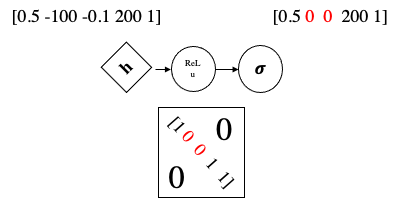

# Backprop

$$\chain{\mathcal{L}}{\mbf{W}^1} = \underbrace{\chain{\loss}{\mbf{z}}}_{1\times Z}\underbrace{\chain{\mbf{z}}{\sigma}}_{Z\times \Sigma}\underbrace{\chain{\mbf{\sigma}}{\mbf{h}}}_{\Sigma \times \Sigma}\chain{\mbf{h}}{\mbf{W}^1}$$

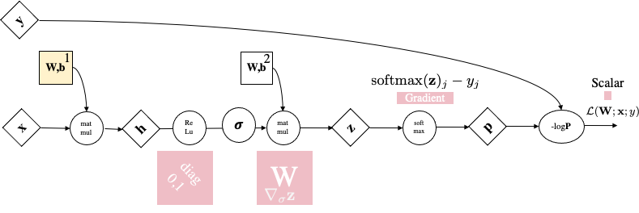

# Jacobian of Activation Functions: implementation exploits sparse structure

- Jacobians for activation functions are **full of zeros**! Since they are diagonal matrix, they are not implemented as a full matrix in practice but as **the diagonal vector.**
- For a $2^{12}=4096$ input and $2^{12}=4096$ output with ReLU, the Jacobian would be of size $2^{24}=16M$!
- This would scale even worse if you think of a **mini batch of 128 examples:** $2^{12+7}=4096\cdot 128$. Jacobian of $2^{(12+7)2}=274B$!

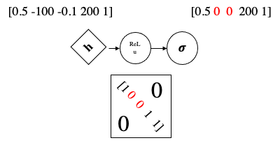

# Backprop

$$\chain{\mathcal{L}}{\mbf{W}^1} = \underbrace{\chain{\loss}{\mbf{z}}}_{1\times Z}\underbrace{\chain{\mbf{z}}{\sigma}}_{Z\times \Sigma}\underbrace{\chain{\mbf{\sigma}}{\mbf{h}}}_{\Sigma \times \Sigma}\chain{\mbf{h}}{\mbf{W}^1}$$

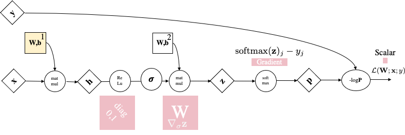

# How to compute $\chain{\mbf{h}}{\mbf{W}^{[1]}}$ ? Matrix to vector function

Matrix notation (I dropped the layer number but $\mbf{W}$ is $\mbf{W}^{[1]}$): $$ \mbf{h} = \mbf{W}\mbf{x}+\mbf{b}$$

Vector Notation **(slice a single row)** let's consider the **i-th row of $\mbf{h}$** so $h=\mbf{h}_i$:

$$ h = \mbf{w}^T\mbf{x}+b \quad \text{where } \mbf{w} \text{ selects i-th row of } \mbf{W}$$

# Slice a single row

$$ h = \sum_j w_j x_j + b$$$$\chain{h}{w_j} = x_j$$

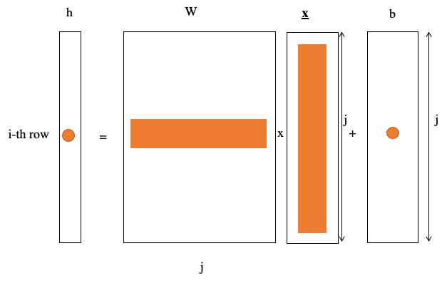

# Gradient of $\mbf{h}$ wrt $\mbf{W}_{ij}$ ($\mbf{W}_{ij} \mapsto \mbf{h}$ )

$$ \mbf{h}_i = \sum_j \mbf{W}_{ij} x_j + \mbf{b}_i$$$$\chain{\mbf{h}}{\mbf{W}_{ij}} = \begin{bmatrix} 0\qquad \\ 0\qquad \\ \vdots\qquad \\ x_{j}~~i^{\text{th}} \text{row}\\ \vdots\qquad \\ 0\qquad \end{bmatrix}$$

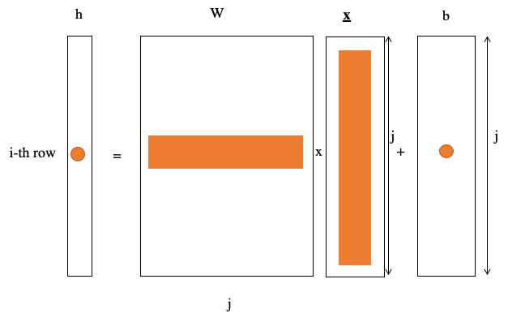

# Backprop $\loss$ to $\mbf{W}_{ij}^{[1]}$

$$\chain{\mathcal{L}}{\mbf{W}_{ij}^{[1]}} = \underbrace{\chain{\loss}{\mbf{z}}}_{1\times Z}\underbrace{\chain{\mbf{z}}{\sigma}}_{Z\times \Sigma~}\underbrace{\chain{\mbf{\sigma}}{\mbf{h}}}_{~\Sigma \times \Sigma}\underbrace{\chain{\mbf{h}}{\mbf{W}_{ij}^{[1]}}}_{~\Sigma\times 1}$$

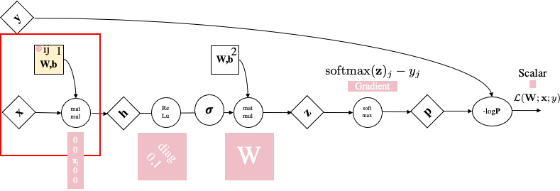

# Backprop $\loss$ to $\mbf{W}_{ij}^{[1]}$

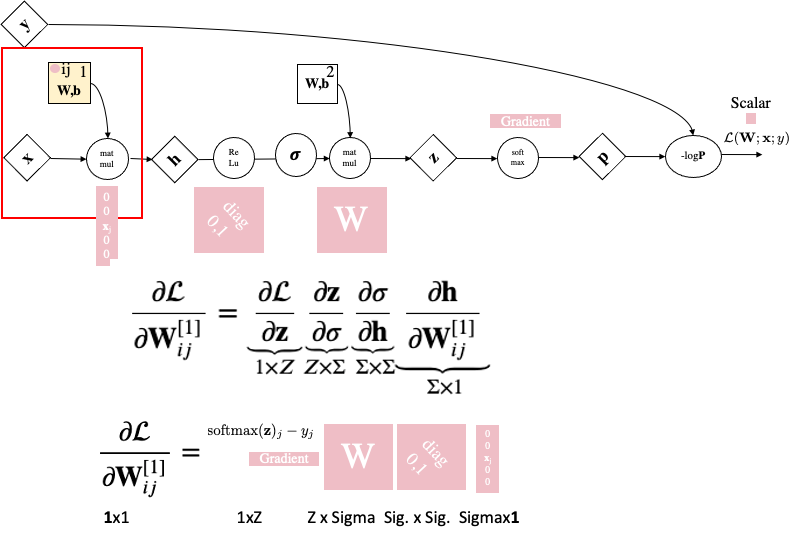

# Backprop $\loss$ to $\mbf{W}_{ij}^{[1]}$ simplified

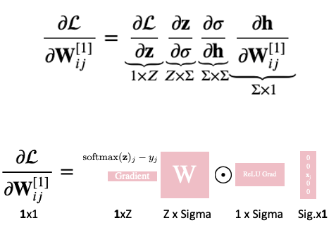

# Backprop $\loss$ to $\mbf{W}_{ij}^{[1]}$ simplified

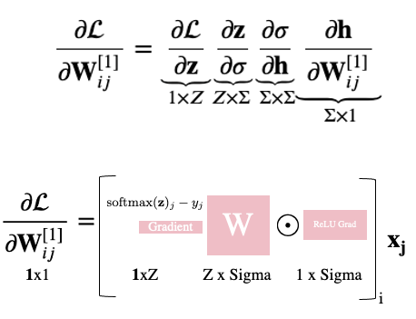

# Backprop $\loss$ to $\mbf{W}^{[1]}$

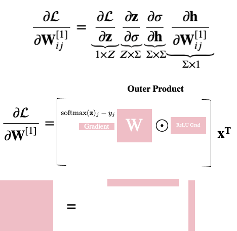

# Once you have gradients on ALL weights $\implies$ We can update

$\forall l \in [1\ldots,L]$:

1. $\mbf{W}^l \leftarrow \mbf{W}^l - \gamma \nabla_{\mbf{W}^l}\mathcal{L}(\mbf{x},y;\{\mbf{W},b\})$
2. $\mbf{b}^l \leftarrow \mbf{b}^l - \gamma \nabla_{\mbf{b}^l}\mathcal{L}(\mbf{x},y;\{\mbf{W},b\})$

# A look back to the Entire Course

**AI & ML are interesting with striking applications** but price to pay...

- *Solid math background* (probability, statistics, linear algebra, calculus)
- Computer scientist formulates/interprets math and knows what is best to turn it into computational system
- Have critical minds on how to evaluate ML systems

# A look back to the Entire Course

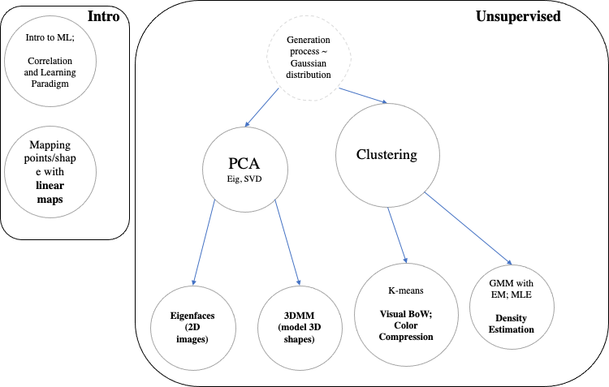

# A look back to the Entire Course

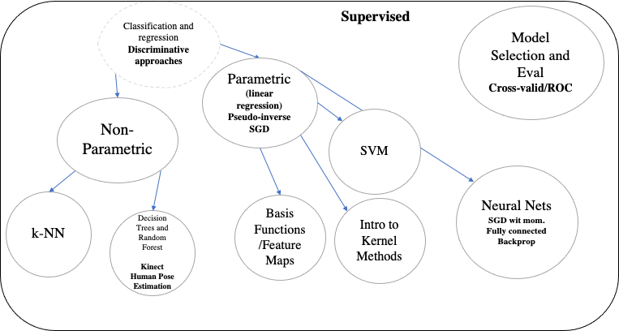

# That's all folks! 👋🏼